# Credit Card Users Churn Prediction

## Problem Statement

### Business Context

The Thera bank recently saw a steep decline in the number of users of their credit card, credit cards are a good source of income for banks because of different kinds of fees charged by the banks like annual fees, balance transfer fees, and cash advance fees, late payment fees, foreign transaction fees, and others. Some fees are charged to every user irrespective of usage, while others are charged under specified circumstances.

Customers’ leaving credit cards services would lead bank to loss, so the bank wants to analyze the data of customers and identify the customers who will leave their credit card services and reason for same – so that bank could improve upon those areas

You as a Data scientist at Thera bank need to come up with a classification model that will help the bank improve its services so that customers do not renounce their credit cards

### Data Description

- CLIENTNUM: Client number. Unique identifier for the customer holding the account
- Attrition_Flag: Internal event (customer activity) variable - if the account is closed then "Attrited Customer" else "Existing Customer"
- Customer_Age: Age in Years
- Gender: Gender of the account holder
- Dependent_count: Number of dependents
- Education_Level: Educational Qualification of the account holder - Graduate, High School, Unknown, Uneducated, College(refers to college student), Post-Graduate, Doctorate
- Marital_Status: Marital Status of the account holder
- Income_Category: Annual Income Category of the account holder
- Card_Category: Type of Card
- Months_on_book: Period of relationship with the bank (in months)
- Total_Relationship_Count: Total no. of products held by the customer
- Months_Inactive_12_mon: No. of months inactive in the last 12 months
- Contacts_Count_12_mon: No. of Contacts in the last 12 months
- Credit_Limit: Credit Limit on the Credit Card
- Total_Revolving_Bal: Total Revolving Balance on the Credit Card
- Avg_Open_To_Buy: Open to Buy Credit Line (Average of last 12 months)
- Total_Amt_Chng_Q4_Q1: Change in Transaction Amount (Q4 over Q1)
- Total_Trans_Amt: Total Transaction Amount (Last 12 months)
- Total_Trans_Ct: Total Transaction Count (Last 12 months)
- Total_Ct_Chng_Q4_Q1: Change in Transaction Count (Q4 over Q1)
- Avg_Utilization_Ratio: Average Card Utilization Ratio

#### What Is a Revolving Balance?

- If we don't pay the balance of the revolving credit account in full every month, the unpaid portion carries over to the next month. That's called a revolving balance

##### What is the Average Open to buy?

- 'Open to Buy' means the amount left on your credit card to use. Now, this column represents the average of this value for the last 12 months.

##### What is the Average utilization Ratio?

- The Avg_Utilization_Ratio represents how much of the available credit the customer spent. This is useful for calculating credit scores.

##### Relation b/w Avg_Open_To_Buy, Credit_Limit and Avg_Utilization_Ratio:

- ( Avg_Open_To_Buy / Credit_Limit ) + Avg_Utilization_Ratio = 1

### **Please read the instructions carefully before starting the project.**

This is a commented Jupyter IPython Notebook file in which all the instructions and tasks to be performed are mentioned.

- Blanks '_______' are provided in the notebook that needs to be filled with an appropriate code to get the correct result. With every '_______' blank, there is a comment that briefly describes what needs to be filled in the blank space.
- Identify the task to be performed correctly, and only then proceed to write the required code.
- Fill the code wherever asked by the commented lines like "# write your code here" or "# complete the code". Running incomplete code may throw error.
- Please run the codes in a sequential manner from the beginning to avoid any unnecessary errors.
- Add the results/observations (wherever mentioned) derived from the analysis in the presentation and submit the same.

## Importing necessary libraries

```python
# Installing the libraries with the specified version.
# uncomment and run the following line if Google Colab is being used
!pip install xgboost
!pip install pandas scikit-learn
!pip install imbalanced-learn
```

```python
import pandas as pd
import numpy as np
import matplotlib.pyplot as plt
%matplotlib inline
import warnings
warnings.filterwarnings('ignore')
import seaborn as sns
from sklearn import metrics
from sklearn.model_selection import (
    train_test_split,
    GridSearchCV,
    train_test_split,
    RandomizedSearchCV,
    StratifiedKFold,
    cross_val_score
)
from sklearn.impute import SimpleImputer
from sklearn.ensemble import (
    BaggingClassifier,
    RandomForestClassifier,
    AdaBoostClassifier,
    GradientBoostingClassifier
)
from sklearn.preprocessing import OneHotEncoder, LabelEncoder
from sklearn.linear_model import LogisticRegression
from sklearn.tree import DecisionTreeClassifier
from sklearn.metrics import (
    accuracy_score,
    recall_score,
    precision_score,
    f1_score,
    roc_auc_score,
    confusion_matrix,
    classification_report
)
from xgboost import XGBClassifier
from imblearn.over_sampling import SMOTE
from imblearn.under_sampling import RandomUnderSampler
```

**Note**: *After running the above cell, kindly restart the notebook kernel and run all cells sequentially from the start again*.

## Loading the dataset

- Used Google Colab to mount and execute this project

```python
from google.colab import drive
drive.mount('/content/drive')
```

```python
url = "/content/drive/MyDrive/AIMLColab/Machine Learning/Advanced Machine Learning/ML Project/BankChurners.csv"
cardChurnData = pd.read_csv(url)
df = cardChurnData.copy()
```

## Data Overview

### Checking shape, Information about Metadata, rows and colums and few Data

```python
df.shape
```

```
(10127, 21)
```

```python
print("There are", df.shape[0], 'rows and', df.shape[1], "columns.")
```

```
There are 10127 rows and 21 columns.
```

```python
df.info()
```

```
<class 'pandas.core.frame.DataFrame'>
RangeIndex: 10127 entries, 0 to 10126
Data columns (total 21 columns):
 #   Column                    Non-Null Count  Dtype
---  ------                    --------------  -----
 0   CLIENTNUM                 10127 non-null  int64
 1   Attrition_Flag            10127 non-null  object
 2   Customer_Age              10127 non-null  int64
 3   Gender                    10127 non-null  object
 4   Dependent_count           10127 non-null  int64
 5   Education_Level           8608 non-null   object
 6   Marital_Status            9378 non-null   object
 7   Income_Category           10127 non-null  object
 8   Card_Category             10127 non-null  object
 9   Months_on_book            10127 non-null  int64
 10  Total_Relationship_Count  10127 non-null  int64
 11  Months_Inactive_12_mon    10127 non-null  int64
 12  Contacts_Count_12_mon     10127 non-null  int64
 13  Credit_Limit              10127 non-null  float64
 14  Total_Revolving_Bal       10127 non-null  int64
 15  Avg_Open_To_Buy           10127 non-null  float64
 16  Total_Amt_Chng_Q4_Q1      10127 non-null  float64
 17  Total_Trans_Amt           10127 non-null  int64
 18  Total_Trans_Ct            10127 non-null  int64
 19  Total_Ct_Chng_Q4_Q1       10127 non-null  float64
 20  Avg_Utilization_Ratio     10127 non-null  float64
dtypes: float64(5), int64(10), object(6)
memory usage: 1.6+ MB
```

```python
df.head(5)
```

|  | CLIENTNUM | Attrition_Flag | Customer_Age | Gender | Dependent_count | Education_Level | Marital_Status | Income_Category | Card_Category | Months_on_book | ... | Months_Inactive_12_mon | Contacts_Count_12_mon | Credit_Limit | Total_Revolving_Bal | Avg_Open_To_Buy | Total_Amt_Chng_Q4_Q1 | Total_Trans_Amt | Total_Trans_Ct | Total_Ct_Chng_Q4_Q1 | Avg_Utilization_Ratio |
| --- | --- | --- | --- | --- | --- | --- | --- | --- | --- | --- | --- | --- | --- | --- | --- | --- | --- | --- | --- | --- | --- |
| 0 | 768805383 | Existing Customer | 45 | M | 3 | High School | Married | $60K - $80K | Blue | 39 | ... | 1 | 3 | 12691.0 | 777 | 11914.0 | 1.335 | 1144 | 42 | 1.625 | 0.061 |
| 1 | 818770008 | Existing Customer | 49 | F | 5 | Graduate | Single | Less than $40K | Blue | 44 | ... | 1 | 2 | 8256.0 | 864 | 7392.0 | 1.541 | 1291 | 33 | 3.714 | 0.105 |
| 2 | 713982108 | Existing Customer | 51 | M | 3 | Graduate | Married | $80K - $120K | Blue | 36 | ... | 1 | 0 | 3418.0 | 0 | 3418.0 | 2.594 | 1887 | 20 | 2.333 | 0.000 |
| 3 | 769911858 | Existing Customer | 40 | F | 4 | High School | NaN | Less than $40K | Blue | 34 | ... | 4 | 1 | 3313.0 | 2517 | 796.0 | 1.405 | 1171 | 20 | 2.333 | 0.760 |
| 4 | 709106358 | Existing Customer | 40 | M | 3 | Uneducated | Married | $60K - $80K | Blue | 21 | ... | 1 | 0 | 4716.0 | 0 | 4716.0 | 2.175 | 816 | 28 | 2.500 | 0.000 |

5 rows × 21 columns

```python
df.tail(5)
```

|  | CLIENTNUM | Attrition_Flag | Customer_Age | Gender | Dependent_count | Education_Level | Marital_Status | Income_Category | Card_Category | Months_on_book | ... | Months_Inactive_12_mon | Contacts_Count_12_mon | Credit_Limit | Total_Revolving_Bal | Avg_Open_To_Buy | Total_Amt_Chng_Q4_Q1 | Total_Trans_Amt | Total_Trans_Ct | Total_Ct_Chng_Q4_Q1 | Avg_Utilization_Ratio |
| --- | --- | --- | --- | --- | --- | --- | --- | --- | --- | --- | --- | --- | --- | --- | --- | --- | --- | --- | --- | --- | --- |
| 10122 | 772366833 | Existing Customer | 50 | M | 2 | Graduate | Single | $40K - $60K | Blue | 40 | ... | 2 | 3 | 4003.0 | 1851 | 2152.0 | 0.703 | 15476 | 117 | 0.857 | 0.462 |
| 10123 | 710638233 | Attrited Customer | 41 | M | 2 | NaN | Divorced | $40K - $60K | Blue | 25 | ... | 2 | 3 | 4277.0 | 2186 | 2091.0 | 0.804 | 8764 | 69 | 0.683 | 0.511 |
| 10124 | 716506083 | Attrited Customer | 44 | F | 1 | High School | Married | Less than $40K | Blue | 36 | ... | 3 | 4 | 5409.0 | 0 | 5409.0 | 0.819 | 10291 | 60 | 0.818 | 0.000 |
| 10125 | 717406983 | Attrited Customer | 30 | M | 2 | Graduate | NaN | $40K - $60K | Blue | 36 | ... | 3 | 3 | 5281.0 | 0 | 5281.0 | 0.535 | 8395 | 62 | 0.722 | 0.000 |
| 10126 | 714337233 | Attrited Customer | 43 | F | 2 | Graduate | Married | Less than $40K | Silver | 25 | ... | 2 | 4 | 10388.0 | 1961 | 8427.0 | 0.703 | 10294 | 61 | 0.649 | 0.189 |

5 rows × 21 columns

### Check Unique and Null values

```python
df['Attrition_Flag'].unique()
```

```
array(['Existing Customer', 'Attrited Customer'], dtype=object)
```

```python
df['Gender'].unique()
```

```
array(['M', 'F'], dtype=object)
```

```python
df['Education_Level'].unique()
```

```
array(['High School', 'Graduate', 'Uneducated', nan, 'College',
       'Post-Graduate', 'Doctorate'], dtype=object)
```

```python
df['Marital_Status'].unique()
```

```
array(['Married', 'Single', nan, 'Divorced'], dtype=object)
```

```python
df['Card_Category'].unique()
```

```
array(['Blue', 'Gold', 'Silver', 'Platinum'], dtype=object)
```

```python
df['Income_Category'].unique()
```

```
array(['$60K - $80K', 'Less than $40K', '$80K - $120K', '$40K - $60K',
       '$120K +', 'abc'], dtype=object)
```

```python
df['Months_on_book'].unique()
```

```
array([39, 44, 36, 34, 21, 46, 27, 31, 54, 30, 48, 37, 56, 42, 49, 33, 28,
       38, 41, 43, 45, 52, 40, 50, 35, 47, 32, 20, 29, 25, 53, 24, 55, 23,
       22, 26, 13, 51, 19, 15, 17, 18, 16, 14])
```

```python
df['Total_Relationship_Count'].unique()
```

```
array([5, 6, 4, 3, 2, 1])
```

```python
df['Months_Inactive_12_mon'].unique()
```

```
array([1, 4, 2, 3, 6, 0, 5])
```

```python
df['Contacts_Count_12_mon'].unique()
```

```
array([3, 2, 0, 1, 4, 5, 6])
```

```python
df.isnull().sum()
```

|  | 0 |
| --- | --- |
| CLIENTNUM | 0 |
| Attrition_Flag | 0 |
| Customer_Age | 0 |
| Gender | 0 |
| Dependent_count | 0 |
| Education_Level | 1519 |
| Marital_Status | 749 |
| Income_Category | 0 |
| Card_Category | 0 |
| Months_on_book | 0 |
| Total_Relationship_Count | 0 |
| Months_Inactive_12_mon | 0 |
| Contacts_Count_12_mon | 0 |
| Credit_Limit | 0 |
| Total_Revolving_Bal | 0 |
| Avg_Open_To_Buy | 0 |
| Total_Amt_Chng_Q4_Q1 | 0 |
| Total_Trans_Amt | 0 |
| Total_Trans_Ct | 0 |
| Total_Ct_Chng_Q4_Q1 | 0 |
| Avg_Utilization_Ratio | 0 |

**dtype:** int64

### Removing CLIENTNUM and checking shape again

```python
df.drop(["CLIENTNUM"], axis=1, inplace=True)
```

```python
df.info()
```

```
<class 'pandas.core.frame.DataFrame'>
RangeIndex: 10127 entries, 0 to 10126
Data columns (total 20 columns):
 #   Column                    Non-Null Count  Dtype
---  ------                    --------------  -----
 0   Attrition_Flag            10127 non-null  object
 1   Customer_Age              10127 non-null  int64
 2   Gender                    10127 non-null  object
 3   Dependent_count           10127 non-null  int64
 4   Education_Level           8608 non-null   object
 5   Marital_Status            9378 non-null   object
 6   Income_Category           10127 non-null  object
 7   Card_Category             10127 non-null  object
 8   Months_on_book            10127 non-null  int64
 9   Total_Relationship_Count  10127 non-null  int64
 10  Months_Inactive_12_mon    10127 non-null  int64
 11  Contacts_Count_12_mon     10127 non-null  int64
 12  Credit_Limit              10127 non-null  float64
 13  Total_Revolving_Bal       10127 non-null  int64
 14  Avg_Open_To_Buy           10127 non-null  float64
 15  Total_Amt_Chng_Q4_Q1      10127 non-null  float64
 16  Total_Trans_Amt           10127 non-null  int64
 17  Total_Trans_Ct            10127 non-null  int64
 18  Total_Ct_Chng_Q4_Q1       10127 non-null  float64
 19  Avg_Utilization_Ratio     10127 non-null  float64
dtypes: float64(5), int64(9), object(6)
memory usage: 1.5+ MB
```

### Checking duplicates and statical summary

```python
print("There are ",df.duplicated().sum(), " duplicates")
```

```
There are  0  duplicates
```

```python
df.describe().apply(lambda x: x.apply('{0:.3f}'.format))
```

|  | Customer_Age | Dependent_count | Months_on_book | Total_Relationship_Count | Months_Inactive_12_mon | Contacts_Count_12_mon | Credit_Limit | Total_Revolving_Bal | Avg_Open_To_Buy | Total_Amt_Chng_Q4_Q1 | Total_Trans_Amt | Total_Trans_Ct | Total_Ct_Chng_Q4_Q1 | Avg_Utilization_Ratio |
| --- | --- | --- | --- | --- | --- | --- | --- | --- | --- | --- | --- | --- | --- | --- |
| count | 10127.000 | 10127.000 | 10127.000 | 10127.000 | 10127.000 | 10127.000 | 10127.000 | 10127.000 | 10127.000 | 10127.000 | 10127.000 | 10127.000 | 10127.000 | 10127.000 |
| mean | 46.326 | 2.346 | 35.928 | 3.813 | 2.341 | 2.455 | 8631.954 | 1162.814 | 7469.140 | 0.760 | 4404.086 | 64.859 | 0.712 | 0.275 |
| std | 8.017 | 1.299 | 7.986 | 1.554 | 1.011 | 1.106 | 9088.777 | 814.987 | 9090.685 | 0.219 | 3397.129 | 23.473 | 0.238 | 0.276 |
| min | 26.000 | 0.000 | 13.000 | 1.000 | 0.000 | 0.000 | 1438.300 | 0.000 | 3.000 | 0.000 | 510.000 | 10.000 | 0.000 | 0.000 |
| 25% | 41.000 | 1.000 | 31.000 | 3.000 | 2.000 | 2.000 | 2555.000 | 359.000 | 1324.500 | 0.631 | 2155.500 | 45.000 | 0.582 | 0.023 |
| 50% | 46.000 | 2.000 | 36.000 | 4.000 | 2.000 | 2.000 | 4549.000 | 1276.000 | 3474.000 | 0.736 | 3899.000 | 67.000 | 0.702 | 0.176 |
| 75% | 52.000 | 3.000 | 40.000 | 5.000 | 3.000 | 3.000 | 11067.500 | 1784.000 | 9859.000 | 0.859 | 4741.000 | 81.000 | 0.818 | 0.503 |
| max | 73.000 | 5.000 | 56.000 | 6.000 | 6.000 | 6.000 | 34516.000 | 2517.000 | 34516.000 | 3.397 | 18484.000 | 139.000 | 3.714 | 0.999 |

### Data observation on Object type

```python
df.describe(include=["object"]).T
```

|  | count | unique | top | freq |
| --- | --- | --- | --- | --- |
| Attrition_Flag | 10127 | 2 | Existing Customer | 8500 |
| Gender | 10127 | 2 | F | 5358 |
| Education_Level | 8608 | 6 | Graduate | 3128 |
| Marital_Status | 9378 | 3 | Married | 4687 |
| Income_Category | 10127 | 6 | Less than $40K | 3561 |
| Card_Category | 10127 | 4 | Blue | 9436 |

```python
for i in df.describe(include=["object"]).columns:
    print("Unique values in", i, "are :")
    print(df[i].value_counts())
    print("*" * 50)
```

```
Unique values in Attrition_Flag are :
Attrition_Flag
Existing Customer    8500
Attrited Customer    1627
Name: count, dtype: int64
Unique values in Gender are :
Gender
F    5358
M    4769
Name: count, dtype: int64
Unique values in Education_Level are :
Education_Level
Graduate         3128
High School      2013
Uneducated       1487
College          1013
Post-Graduate     516
Doctorate         451
Name: count, dtype: int64
Unique values in Marital_Status are :
Marital_Status
Married     4687
Single      3943
Divorced     748
Name: count, dtype: int64
Unique values in Income_Category are :
Income_Category
Less than $40K    3561
$40K - $60K       1790
$80K - $120K      1535
$60K - $80K       1402
abc               1112
$120K +            727
Name: count, dtype: int64
Unique values in Card_Category are :
Card_Category
Blue        9436
Silver       555
Gold         116
Platinum      20
Name: count, dtype: int64
```

## Exploratory Data Analysis (EDA)

- EDA is an important part of any project involving data.
- It is important to investigate and understand the data better before building a model with it.
- A few questions have been mentioned below which will help you approach the analysis in the right manner and generate insights from the data.
- A thorough analysis of the data, in addition to the questions mentioned below, should be done.
- Lets define reusable-funcation to draw plots for EDA

### Function for analysis using Hist, Box

```python
# function to plot stacked bar chart
# Print the category counts and plot a stacked bar chart
# data: dataframe
# predictor: independent variable
# target: target variable


def stacked_barplot(data, predictor, target):
    count = data[predictor].nunique()
    sorter = data[target].value_counts().index[-1]
    tab1 = pd.crosstab(data[predictor], data[target], margins=True).sort_values(
        by=sorter, ascending=False
    )
    print(tab1)
    print("-" * 120)
    tab = pd.crosstab(data[predictor], data[target], normalize="index").sort_values(
        by=sorter, ascending=False
    )
    tab.plot(kind="bar", stacked=True, figsize=(count + 1, 5))
    plt.legend(
        loc="lower left", frameon=False,
    )
    plt.legend(loc="upper left", bbox_to_anchor=(1, 1))
    plt.show()
```

```python
### re-usable function to Box and Hist plot distributions wrt target
#data: dataframe
#feature: dataframe for a selected column
#target : selected target column
def box_hist_plot_distribution_wrt_target(data, feature, target):

    fig, axs = plt.subplots(2, 2, figsize=(12, 10))

    target_uniq = data[target].unique()

    axs[0, 0].set_title("Hist plot Distribution W.R.T target=" + str(target_uniq[0]))
    sns.histplot(
        data=data[data[target] == target_uniq[0]],
        x=feature,
        kde=True,
        ax=axs[0, 0],
        color="teal",
    )

    axs[0, 1].set_title("Gist plot Distribution W.R.T target=" + str(target_uniq[1]))
    sns.histplot(
        data=data[data[target] == target_uniq[1]],
        x=feature,
        kde=True,
        ax=axs[0, 1],
        color="orange",
    )

    axs[1, 0].set_title("Boxplot W.R.T target")
    sns.boxplot(data=data, x=target, y=feature, ax=axs[1, 0], palette="Spectral")

    axs[1, 1].set_title("Boxplot (without outliers) W.R.T target")
    sns.boxplot(
        data=data,
        x=target,
        y=feature,
        ax=axs[1, 1],
        showfliers=False,
        palette="Spectral",
    )

    plt.tight_layout()
    plt.show()
```

### HistPlot for Total_TransAmt

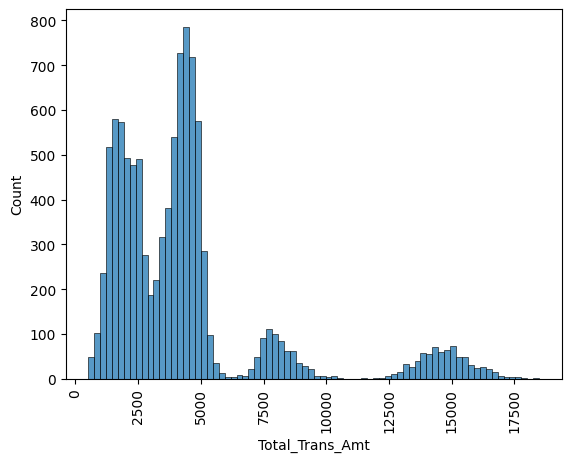

```python
sns.histplot(data=df, x='Total_Trans_Amt', stat='count' )
plt.xticks(rotation=90)
plt.show()
```

### Histplot for Education_Level

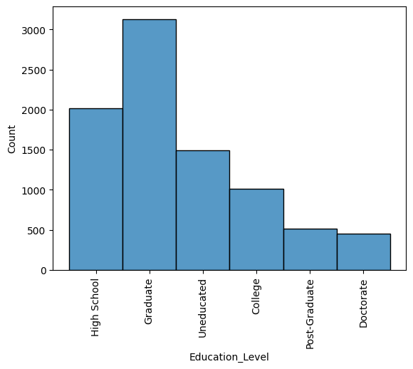

```python
sns.histplot(data=df, x='Education_Level', stat='count' )
plt.xticks(rotation=90)
plt.show()
```

### Histplot for Income_Category

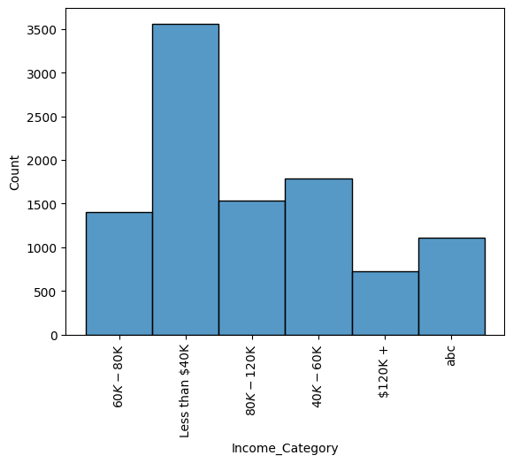

```python
sns.histplot(data=df, x='Income_Category', stat='count' )
plt.xticks(rotation=90)
plt.show()
```

### Distribution of total_ct_Q4_Q1 WRT to Attribution_Flag

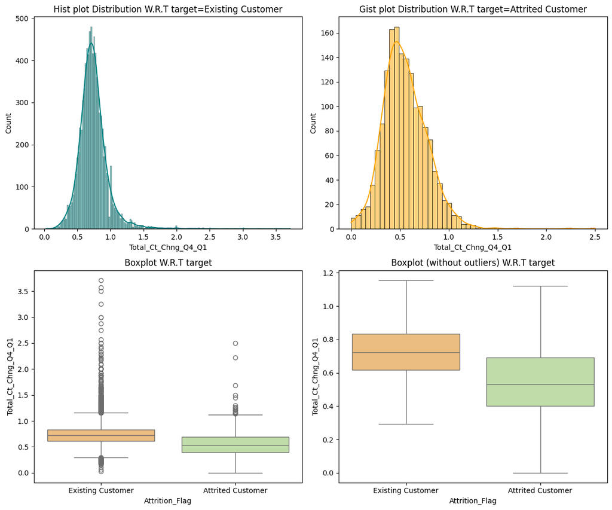

```python
box_hist_plot_distribution_wrt_target(df, 'Total_Ct_Chng_Q4_Q1', 'Attrition_Flag')
```

### Inactive Customer Activity by Account Status

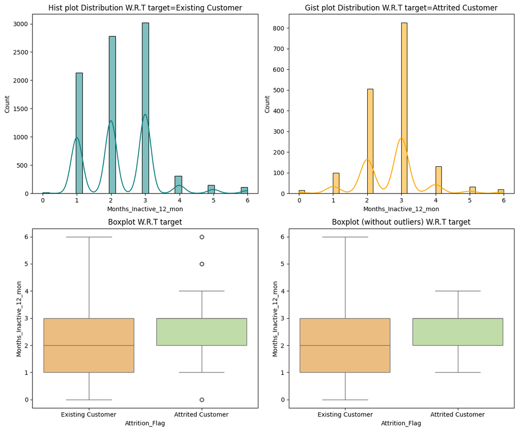

```python
box_hist_plot_distribution_wrt_target(df, 'Months_Inactive_12_mon', 'Attrition_Flag')
```

### Co-Relation between Attributes

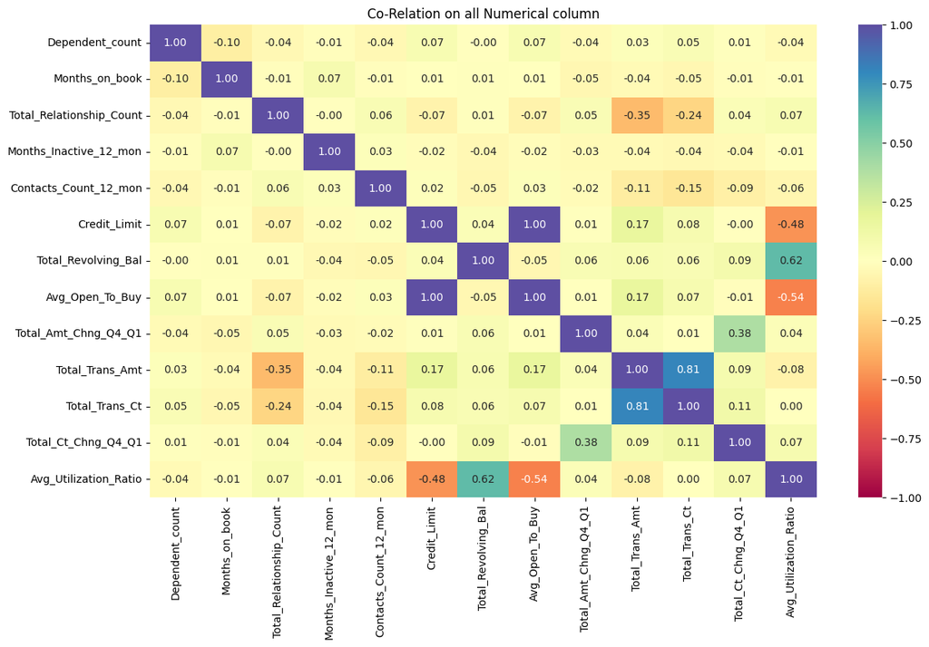

```python
# defining the size of the plot
plt.figure(figsize=(14, 8))
# defining the list of numerical features to plot
num_features = ['Dependent_count', 'Months_on_book', 'Total_Relationship_Count', 'Months_Inactive_12_mon', 'Contacts_Count_12_mon', 'Credit_Limit', 'Total_Revolving_Bal', 'Avg_Open_To_Buy', 'Total_Amt_Chng_Q4_Q1', 'Total_Trans_Amt', 'Total_Trans_Ct', 'Total_Ct_Chng_Q4_Q1', 'Avg_Utilization_Ratio']

# plotting the heatmap for correlation
sns.heatmap(
    df[num_features].corr(),annot=True, vmin=-1, vmax=1, fmt=".2f", cmap="Spectral"
);
plt.title('Co-Relation on all Numerical column');
```

### **Q&A with analysis**

**1. How is the total transaction amount distributed?**

- Distribution of Total Transaction Amount is right skewed

**2. What is the distribution of the level of education of customers?**

- Distribution of Education Level is right skewed
- 30% of the customers are Graduate, 20% completed high school, 15% are Uneducated and 5% are post graduate and Doctarate.

**3. What is the distribution of the level of income of customers?**

- Distribution of income is little right distributed
- 35% of the customers have income less than 40K, 14% earn 80-120K, 17% earn 40-60K, 7% earn above 120K. But 10% of the customers have provided there income as 'abc'
- **abc** is added as one of the income category, this needs to be treated

**5. How does the number of months a customer was inactive in the last 12 months (`Months_Inactive_12_mon`) vary by the customer's account status (`Attrition_Flag`)?**

- Existing Customers - 20% inactive for 1 month, 25% inactive for 2 month, 30% inactive for 3 month
- Attrited Customer - 8% inactive for 3 month, 6% inactive for 2 month and 1% inactive for 1 month

**6. What are the attributes that have a strong correlation with each other?**

- Avg_Utilization_Ration has positive correlation with Total_Revolving_balance
- Total_Ct_Change_Q4_Q1 has positive correlation with Total_Amt_Change_Q4_Q1
- Total_Trans_Ct has positive correlation with Total_Trans_Amt
- Total_Relation_Count has negative correlation with Total_Trans_Amt and Total_TransCt
- Avg_Utilization_Ration has negative co-relation with Credit_Limit and Avg_Open_To_Buy

**Co-Relation between Metadata**

- This Indicates **Card utiliztion has strong corelation with Revolving balance**
- **More product** customers has it **exihibit negative co-relatio**n with Transaction count and Amount
- **Card utilization** also has negative corelation with **credit limit** and open to **buy new credit line**

### Univariate Analysis

```python
# defining the list of numerical features to plot
num_features = ['Dependent_count', 'Months_on_book', 'Total_Relationship_Count', 'Months_Inactive_12_mon', 'Contacts_Count_12_mon', 'Credit_Limit', 'Total_Revolving_Bal', 'Avg_Open_To_Buy', 'Total_Amt_Chng_Q4_Q1', 'Total_Trans_Amt', 'Total_Trans_Ct', 'Total_Ct_Chng_Q4_Q1', 'Avg_Utilization_Ratio']
```

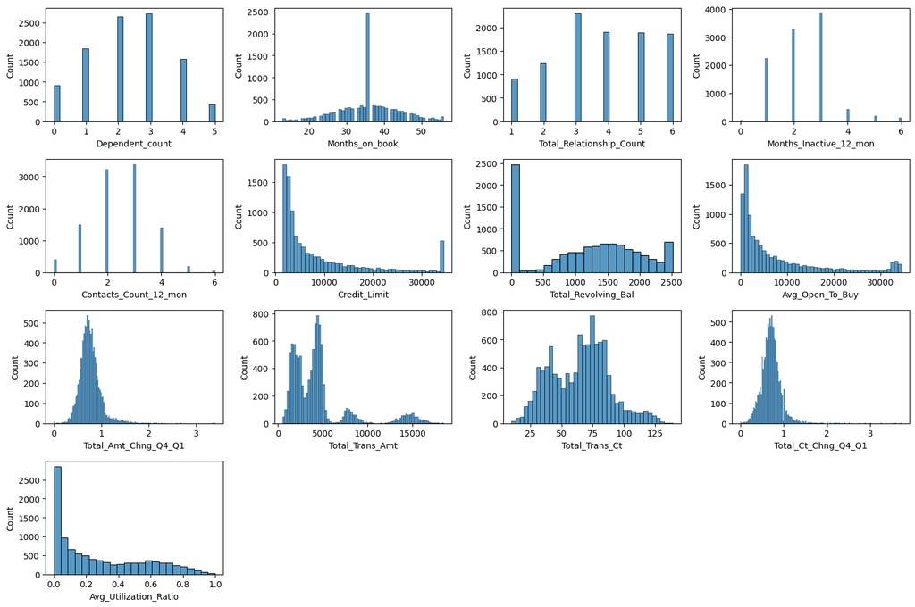

```python
# defining the figure size
plt.figure(figsize=(15, 10))

# plotting the histogram for each numerical feature
for i, feature in enumerate(num_features):
    plt.subplot(4, 4, i+1)    # assign a subplot in the main plot
    sns.histplot(data=df, x=feature)    # plot the histogram

plt.tight_layout();   # to add spacing between plots
```

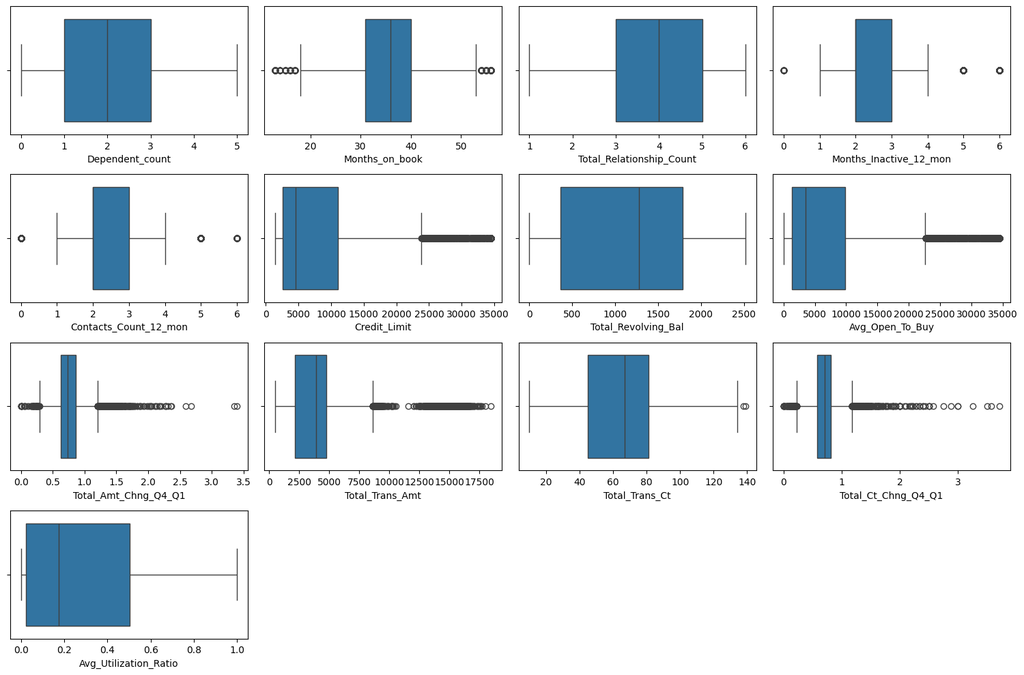

```python
# defining the figure size
plt.figure(figsize=(15, 10))

# plotting the histogram for each numerical feature
for i, feature in enumerate(num_features):
    plt.subplot(4, 4, i+1)    # assign a subplot in the main plot
    sns.boxplot(data=df, x=feature)    # plot the histogram

plt.tight_layout();   # to add spacing between plots
```

### Bivariate Analysis

```
Attrition_Flag  Attrited Customer  Existing Customer    All
Gender
All                          1627               8500  10127
F                             930               4428   5358
M                             697               4072   4769
------------------------------------------------------------------------------------------------------------------------
```

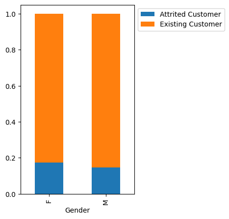

```
Attrition_Flag  Attrited Customer  Existing Customer   All
Marital_Status
All                          1498               7880  9378
Married                       709               3978  4687
Single                        668               3275  3943
Divorced                      121                627   748
------------------------------------------------------------------------------------------------------------------------
```

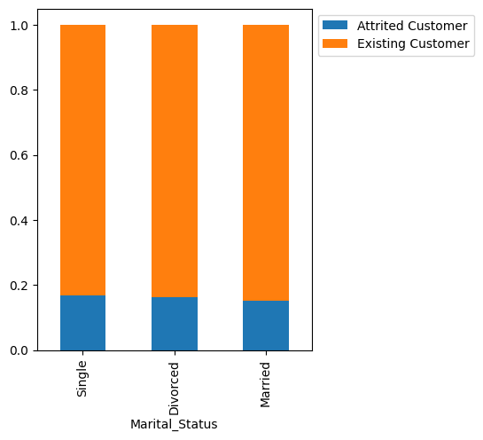

```
Attrition_Flag   Attrited Customer  Existing Customer   All
Education_Level
All                           1371               7237  8608
Graduate                       487               2641  3128
High School                    306               1707  2013
Uneducated                     237               1250  1487
College                        154                859  1013
Doctorate                       95                356   451
Post-Graduate                   92                424   516
------------------------------------------------------------------------------------------------------------------------
```

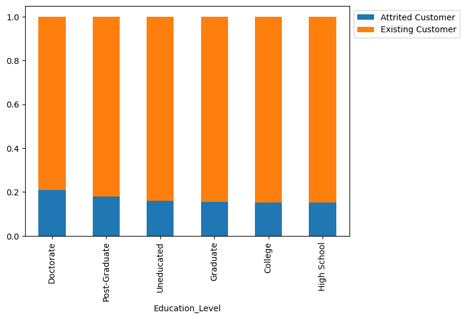

```
Attrition_Flag   Attrited Customer  Existing Customer    All
Income_Category
All                           1627               8500  10127
Less than $40K                 612               2949   3561
$40K - $60K                    271               1519   1790
$80K - $120K                   242               1293   1535
$60K - $80K                    189               1213   1402
abc                            187                925   1112
$120K +                        126                601    727
------------------------------------------------------------------------------------------------------------------------
```

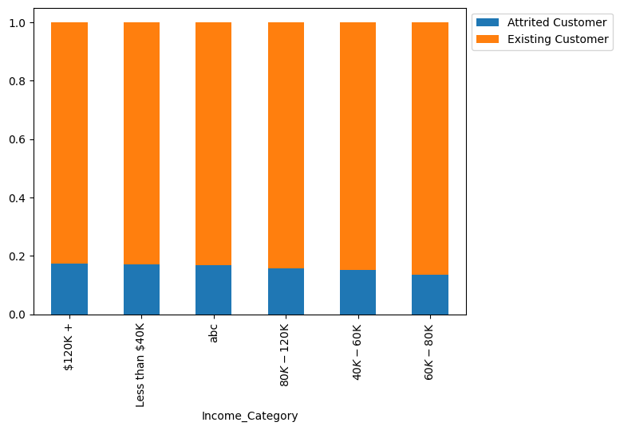

```
Attrition_Flag         Attrited Customer  Existing Customer    All
Contacts_Count_12_mon
All                                 1627               8500  10127
3                                    681               2699   3380
2                                    403               2824   3227
4                                    315               1077   1392
1                                    108               1391   1499
5                                     59                117    176
6                                     54                  0     54
0                                      7                392    399
------------------------------------------------------------------------------------------------------------------------
```

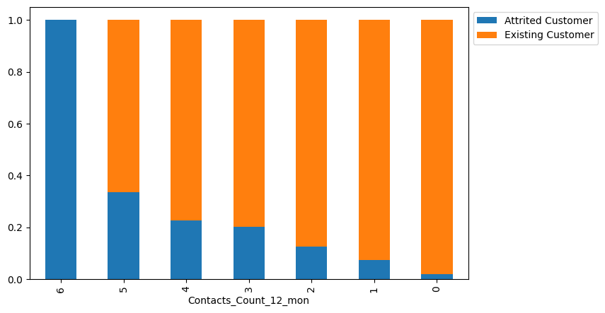

```
Attrition_Flag          Attrited Customer  Existing Customer    All
Months_Inactive_12_mon
All                                  1627               8500  10127
3                                     826               3020   3846
2                                     505               2777   3282
4                                     130                305    435
1                                     100               2133   2233
5                                      32                146    178
6                                      19                105    124
0                                      15                 14     29
------------------------------------------------------------------------------------------------------------------------
```

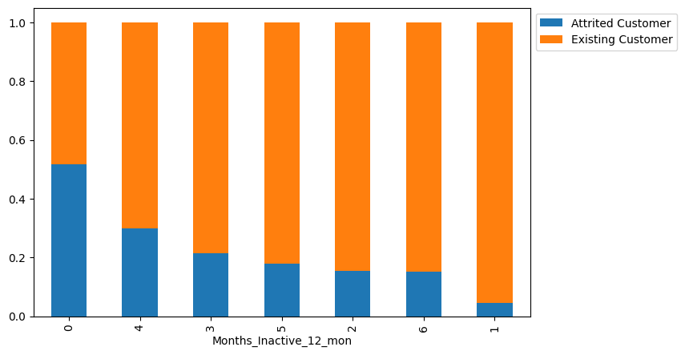

```
Attrition_Flag            Attrited Customer  Existing Customer    All
Total_Relationship_Count
All                                    1627               8500  10127
3                                       400               1905   2305
2                                       346                897   1243
1                                       233                677    910
5                                       227               1664   1891
4                                       225               1687   1912
6                                       196               1670   1866
------------------------------------------------------------------------------------------------------------------------
```

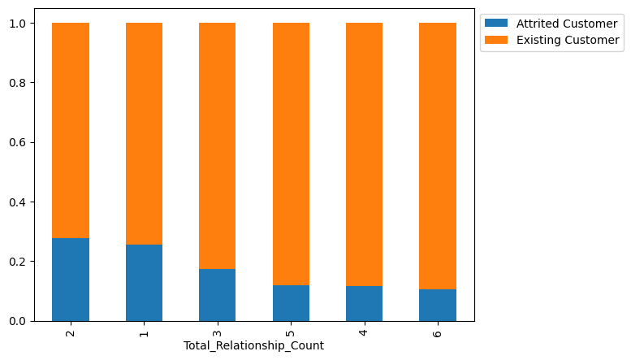

```
Attrition_Flag   Attrited Customer  Existing Customer    All
Dependent_count
All                           1627               8500  10127
3                              482               2250   2732
2                              417               2238   2655
1                              269               1569   1838
4                              260               1314   1574
0                              135                769    904
5                               64                360    424
------------------------------------------------------------------------------------------------------------------------
```

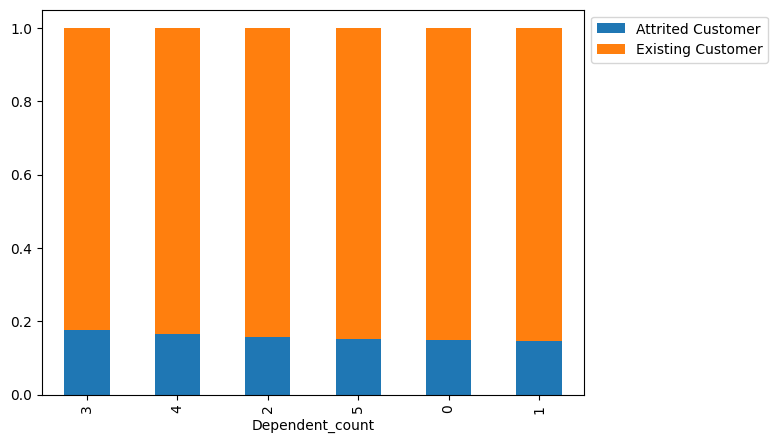

```python
stack_barplot_feature = ['Gender', 'Marital_Status', 'Education_Level', 'Income_Category', 'Contacts_Count_12_mon', 'Months_Inactive_12_mon', 'Total_Relationship_Count', 'Dependent_count']
for feature in stack_barplot_feature:
    stacked_barplot(df, feature, 'Attrition_Flag')
```

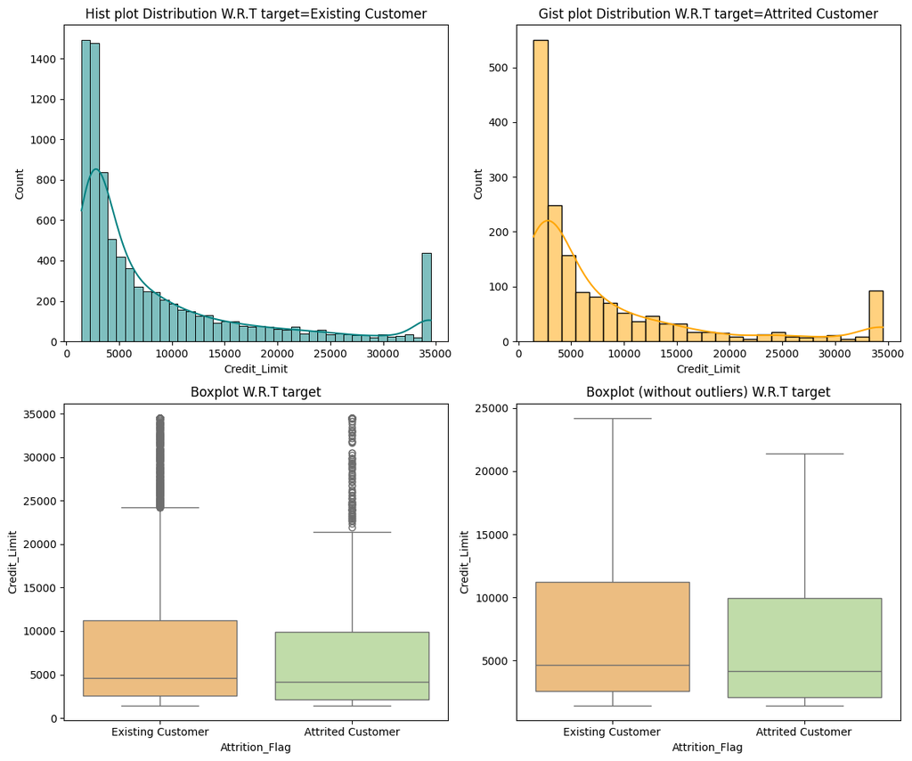

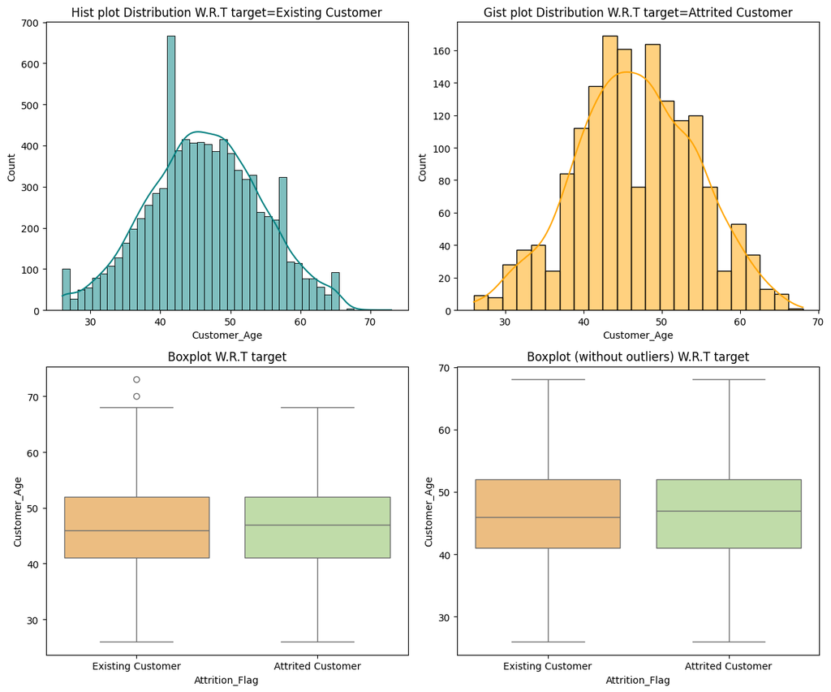

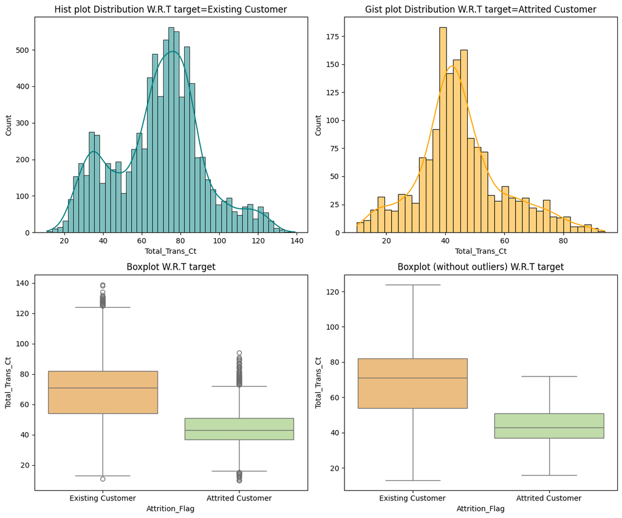

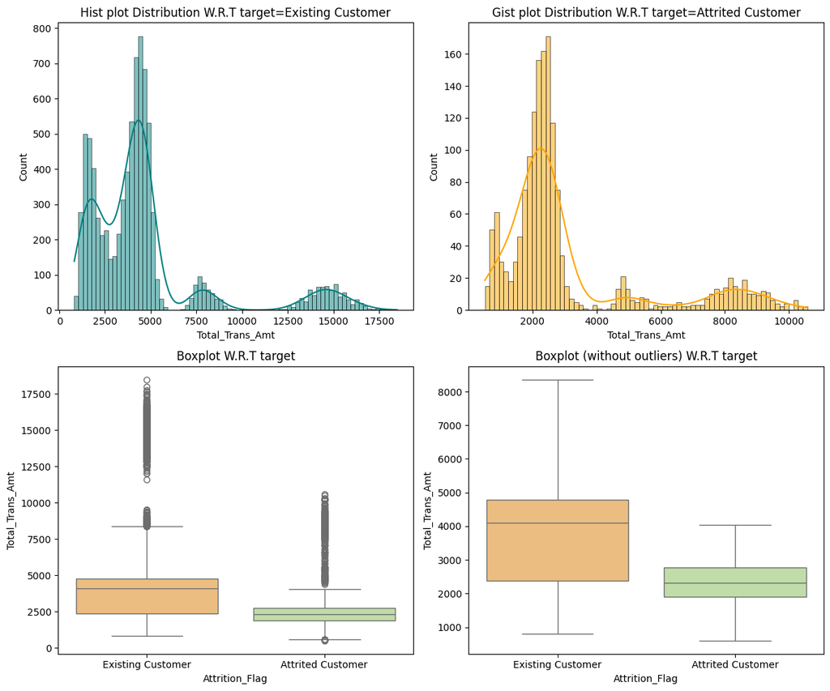

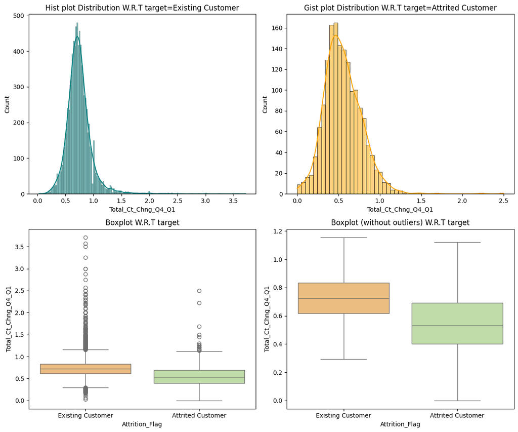

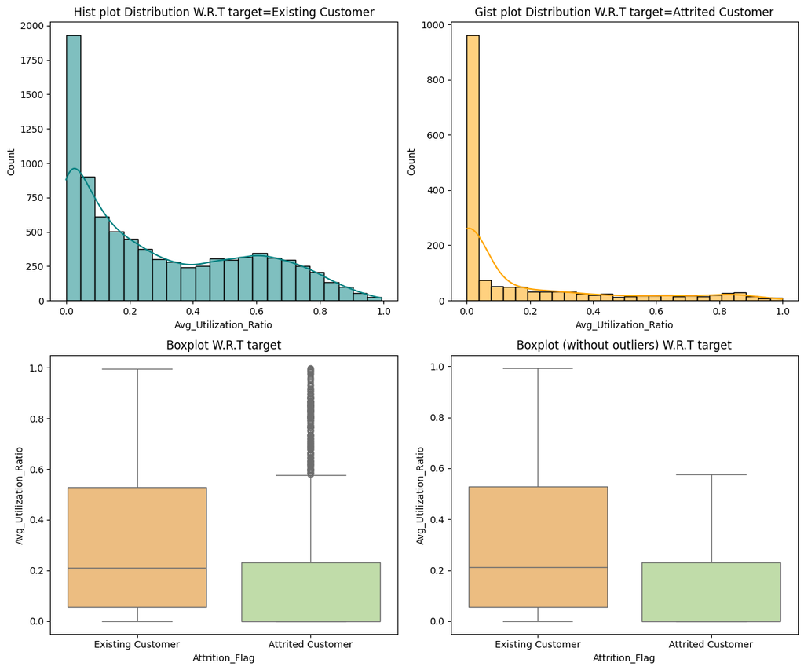

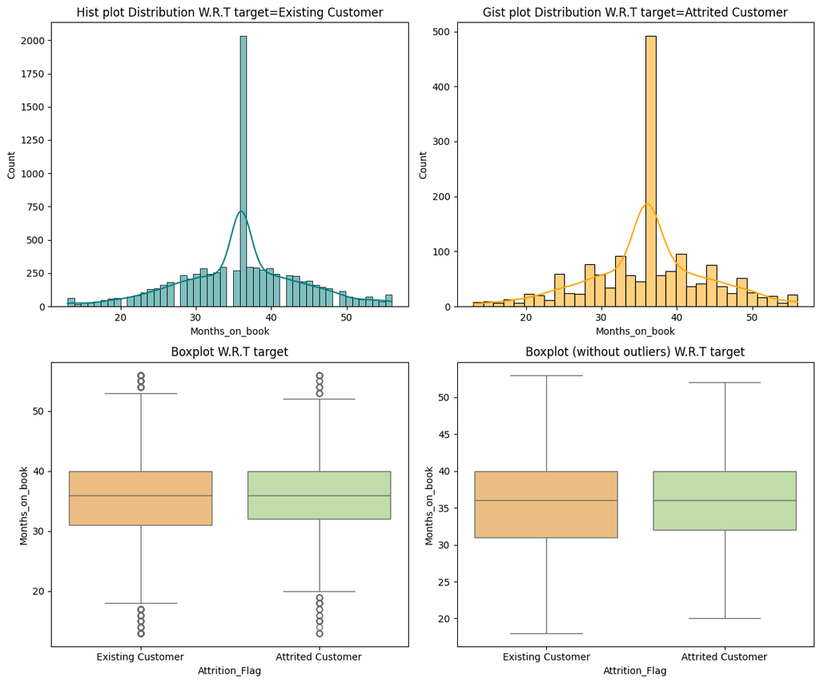

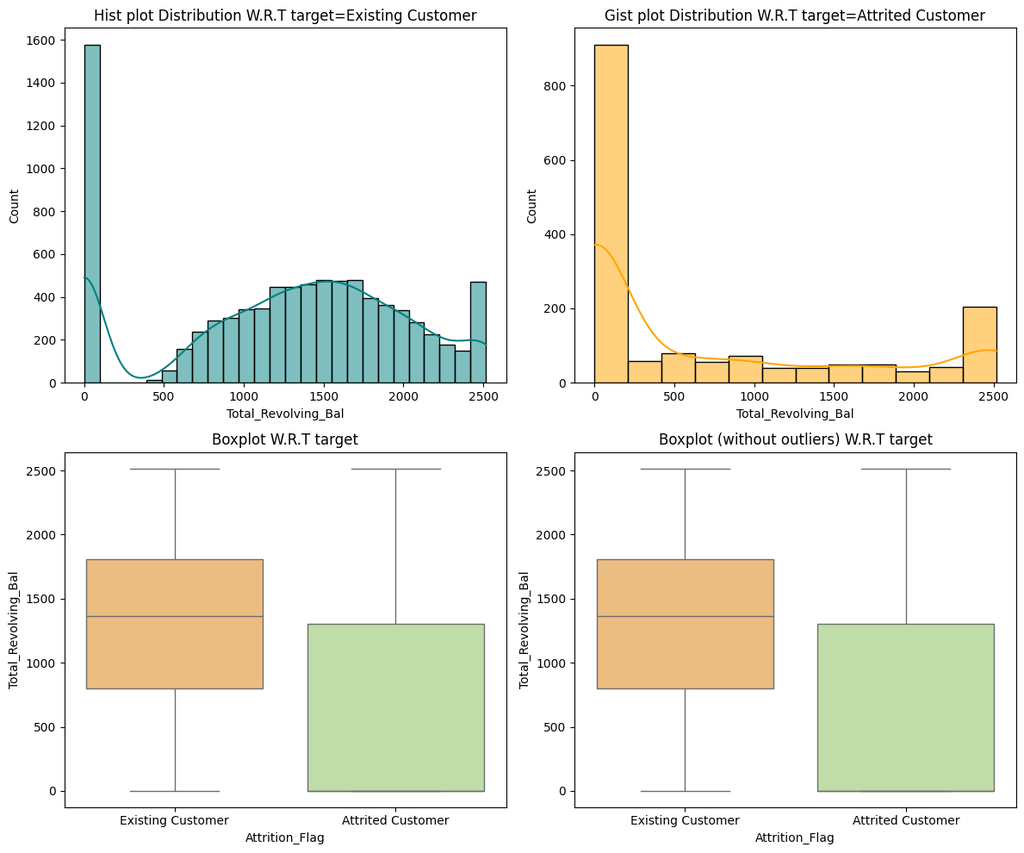

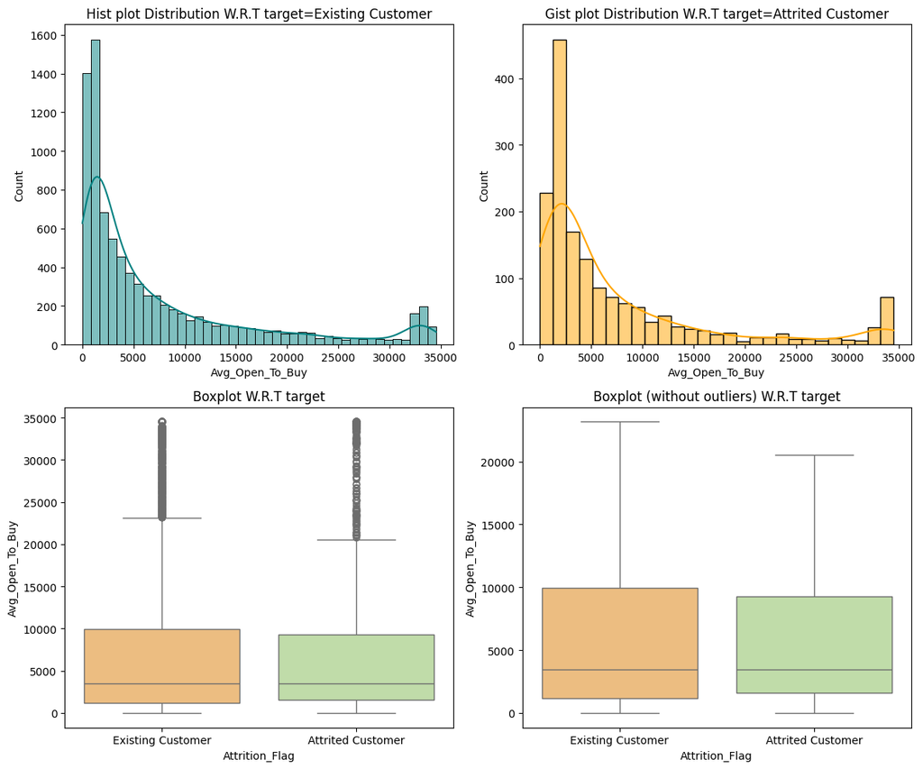

```python
distribution_plot_feature = ['Credit_Limit', 'Customer_Age', 'Total_Trans_Ct', 'Total_Trans_Amt', 'Total_Ct_Chng_Q4_Q1', 'Avg_Utilization_Ratio', 'Months_on_book', 'Total_Revolving_Bal', 'Avg_Open_To_Buy']
for feature in distribution_plot_feature:
    box_hist_plot_distribution_wrt_target(df, feature, 'Attrition_Flag')
```